[figure not shown]

*Hit the space bar or swipe left for next slide*

Introduction

[figure not shown]

Identification of “Chaos Day”

We first needed to find the worst days in terms of 311 complaints. To do this, we utilized Anomaly Detector to analyze anomalies that occurred within all different complaints, and total complaints.

In total, the anomaly detector identified 2914 Days that have Anomalies, 194 Unique Complaints and 599144 Total Complaints.

Within the graphs below you can see on the left plot, a time series of all of the complaints per day for the entire 311 dataset. Anomalies are identified with blue points on the graph, which can be positive anomalies or negative anomalies.

The package ignores seasonality, which was important as certain complaints only occur during specific times of the year, such as Heat and Hot Water, shown below.

We found it suspicious that many of the anomalies occur on the first work day following New Years Day. We therefore chose a day that had ample work time between New Years Eve and our selected Chaos Day.

January 8th, 2015 was chosen specifically because of its number of complaints and 2015 was when 311 started to provide timestamps of complaints throughout the day including hour and minute.

[figure not shown]

We also wanted to take a look at any anomalies that may have occurred on January 8th 2015. We used the anomaly detector to scan every complaint (aggregated per day) for the entire 311 dataset.

The detector was able to pick up 6 anomalies that were associated with the Chaos Day. They are displayed on the Bar Chart below.

The figure on the left shows some of these anomalies (matched by color) throughout the 311 dataset, the anomalies are indicated by the red points.

[figure not shown]

Web Analysis

[figure not shown]

Complaint Types and Descriptors Analysis

We then explored 311 complaints from the time period around the Chaos Day. To analyze the complaints of the week surrounding January 8 2015, we selected the period of 01/05/2015 - 01/11/2015 and plot of the counts of the top five complaints of the week. We can see that complaints of Heat/Hot Water are more than 10 times that of the second most frequent type of complaints. This is expected because it is one of the coldest day of the year. We can see that the second most prevalent complaint is Blocked Driveway and the third is Plumbing, which makes sense given the weather conditions.

[interactive chart not shown]

We then investigated when these five types complaints were reported. With some preliminary statistics, we find that out of the 19833 complaints of Heat/Hot Water, 19832 of them are logged at 12AM. We found this phenomenon to be a feature of the 311 logging system and is therefore not indicative of the actual time complaints were logged. For example, 96.6% of total unsanitary condition complaints and 98.6% of total plumbing complaints are logged at 12AM. As a result, we selected other periods of time for our analysis. Specifically, given that the complaints are reported at discreet time points with random time intervals in between, we choose bar plot to show the count of the top five complaints for each hour we selected. Below is a plot showing the counts of complaints for 3AM, 6AM, 9AM, 12PM, 3PM, 6PM, 9PM. We can see that there are the most Blocked Driveway complaints around 9AM, 3PM, and 9PM. Furthermore, the most Street Light complaints occur around 9AM and 3PM.

[interactive chart not shown]

Next, we look at the descriptors of the complaints of the week surrounding January 8 2015. Much like the previous section, we pick the period of 01/05/2015 - 01/11/2015 and plot of the counts of the top five descriptors of the week. As expected, the top descriptors are Entire Building and Apartment Only, which are associated with Heat/Hot Water complaints. The third most is Street Light Out, which is associated with complaints of Street Light Condition.

[interactive chart not shown]

Similar to how we plot the counts of complaints throughout the day, we plot the counts of descriptors for 3AM, 6AM, 9AM, 12PM, 3PM, 6PM, 9PM using a reactive bar chart. We can see that there are most descriptors about No Access at 9AM and the amount of descriptors about no access is quite stable from 12PM to 9PM. We note that the most descriptors about Pothole and Street Light Out are at 3PM.

[interactive chart not shown]

Exploring Complaints

We further our investigation by plotting the top ten 311 complaint categories for January 8th according to census tracts as shown below.

[interactive chart not shown]

We see that the complaint categories have different distributions throughout New York City. For example, heat and hot water complaints appear to be clustered around the northern edge of Manhattan, in the lower Bronx and around the center of Brooklyn. However, other categories such as unsanitary condition appear to be uniformly distributed throughout the city.

NYC Car Collisions on Jan 08, 2015

We continue our geospatial analysis by investigating whether this was a particularly bad day for traffic accidents.

The time lapse plot (link below) shows the number collisions that occurred on Jan 08, 2015. The collisions will appear at the time they happened. The colors are related to the type of vehicle that was involved in the collision.

[figure not shown]

[Link to D3 NYC Car Collisions](http://bl.ocks.org/minnich49/raw/fbeb70700c7c870ea016a28c4918f322/)

Comparison to Historcal Collisions in NYC

[figure not shown]

Having seen how many collisions were on the Chaos Day, we wanted to know if this behavior is anomalous.

We can see from the red line in the upper left plot, that January 8, 2015 was a pretty typical day in terms of car collisions at 505 total.

There was even a day that had over 900 collisions, which was during a major winter storm.

To insure that this horrible day did not just affect a single burrow, the plot on the right shows the historical distributions for each Borough, where the black dot indicates January 8, 2015.

Relationship Between Agencies, Complaints, and Boroughs

We then investigated the complaints and the resulting agency response.

The 311 Service Requests contain many sub fields including agency and borough. Here we focus on relationship between agencies, boroughs, and complaints. We use Saneky diagrams to show the relationships between these variables. To put January 8th in perspective, we compare both the anomaly day and the complaints from an entire year.

A Sankey diagram of anomaly day is shown below. Here we see the relationship between complaint type and agencies, as well as the relationship between agencies and boroughs.

Sankey diagram between complaints, agencies, and boroughs at anomaly day

In the above diagram, there are many complaints directed to HPD (Housing Preservation & Development) on January 8th. Among these, there are 5225 complaints classified as HEAT/HOT WATER which is the largest complaint category for this day. We also see other complaints such as plumbing or DOOR/WINDOW. Furthermore we observe the relationships between agencies and boroughs. For example, the numbers of complaints directed to HPD are the largest in Brooklyn.

Another Sankey diagram of anomaly day is shown below. In this diagram, we can see the relationship between agencies and boroughs, and the relationship between boroughs and complaints.

Sankey diagram between agencies, boroughs, and complaints at anomaly day

In the diagram above, we can see the direct relationship between borough and complaint type. We can see that complaints of HEAT/HOT WATER are most prevalent in Brooklyn. From this result, we can also assume that some incidents related to water happened at the anomaly day.

A Sankey diagram for a full year of complaints is shown below. In this diagram, we see the relationship between complaint type and agencies, and the relationship between agencies and boroughs. Here, we picked the top three agencies that had largest numbers of complaints on the anomaly day to compare the yearly data and anomaly data.

Sankey diagram between complaints, agencies, and boroughs at 2015

In the diagram above we show the number of complaints directed to HPD, DOT or NYPD during 2015 and 2016. As we can see above, complaints of HEATING are the largest, however, complaints of HEAT/HOT WATER that was the largest numbers of complaints at anomaly day is not the largest in total. Hence, we can say that at the anomaly day, the numbers of complaints of HEAT/HOT WATER was very high compared with annual data. In addition, the numbers of complaints directed to HPD in Brooklyn was the largest (1076902), and it may be possible that houses or buildings at Brooklyn may have some issue related to water or heating.

As shown above, HPD had the most complaints. We then look at the descriptions written in these complaints.

Here is the description information of complains directed to HPD at the anomaly day (Jan/8/2015).

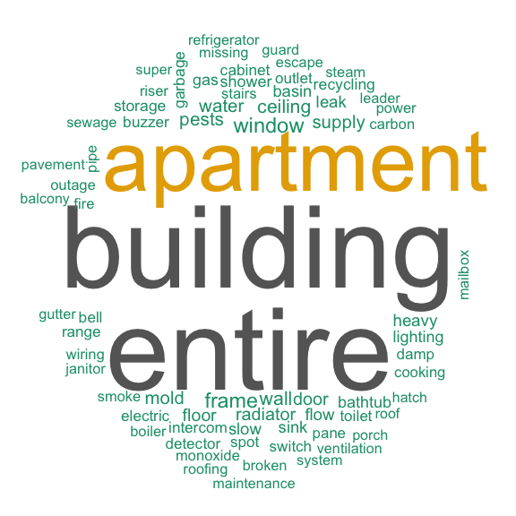

As we can see, words that are related to housing such as ‘building’ and ‘apartment’ are prevalent. From the previous analysis about complaint type, we know that there are many HEAT/HOT WATER complaints. This word cloud is consistent with the distribution of complaints for this day.

Agency Response Time Analysis

The majority of complaints in Jan 2015 went to two agencies: HPD and DOT. We’d like to summarize the efficiency of these agencies in closing complaints assigned to them over an extended time period.

Specifically, we want to look at the window between Jan 1st and Jan 15th, which is a week before/after the Chaos Day Jan 8th. Furthermore, we will focus on the Manhattan borough as it is where the majority of the report authors are located.

We are curious if there is any pattern within agencies. For example, whether HPD’s response time to one type of complaint is affected by the other complaints? How was their efficiency in closing complaints that were created on the Chaos Day compared to other days?

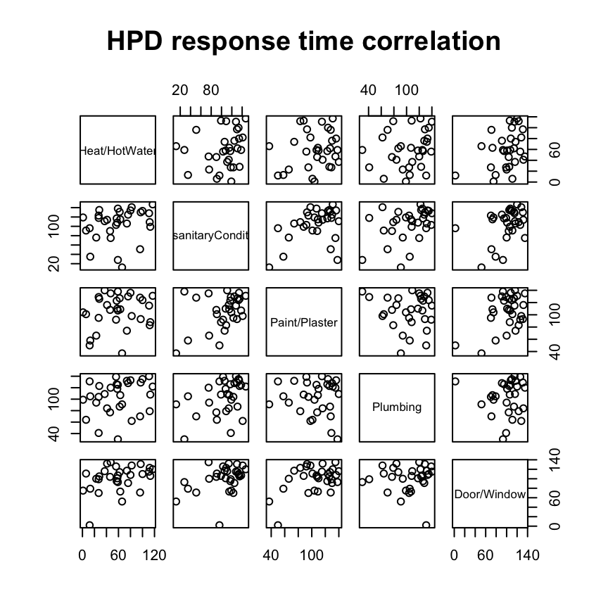

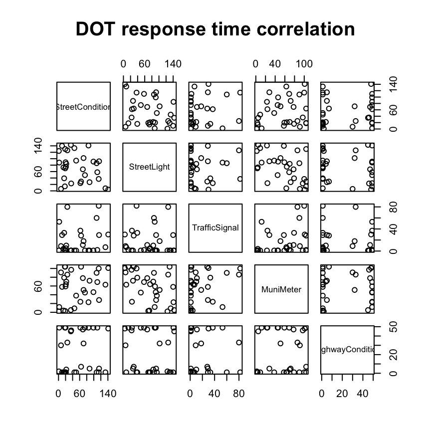

The pair correlations between types of complaints are very random for each agency. We then move on to visualize the response time by complaint categories for two agencies.

[interactive chart not shown]

HPD is relatively efficient in fixing the Heat/Hot Water complaints, which is necessary because these are more urgent when compared to other complaints during the winter days.

This is also the case for complaints created on Jan 8th. If the reader hovers over Jan 8th, they will see that HPD took longer time closing Plumbing, Door/Window, Unsanitary Condition, Paint/Plaster issues than closing Heat/Hot Water complaints.

[interactive chart not shown]

DOT’s response efficiency differs among types of complaints as well, here the contrast between response times is more obvious. Highway Condition and Traffic Signal Condition are more urgent than other cases and as such the DOT may work harder to resolve these issues.

From the visualization, we do not find pattern that could summarize the agency’s response time to different complaints over the week before/after Jan 8th. This is understandable as the urgency of complaints and other exogenous factors may affect the agency’s efficiency.

Prediction Future “Chaos Day”

[figure not shown]

Prediction Model - Approach

We attempted to use time series analysis to predict number of counts per day, however our results were inaccurate due to volatile changes from day to day.

We then turned to Random Forest Regression in order to account for highly non-linear data. While it will be shown this model has difficulties detecting anomalies, we will see that there is still a large benefit for the 311 team in knowing what their next day will be like. This will allow for them to properly staff for the incoming complaints.

We aggregated all of the complaints into daily counts and used the previous 4 days of information to predict the Count of that day(shown below as Day_Lag_1 to Day_Lag_4).

The initial features are the previous 4 days. We attempt to predict Count.

[figure not shown]

Prediction Model - Importance Factors

Model 1: The upper left plot was the initial model that only included the Counts from Daily Lags.

Model 2: The upper right plot was the second model that added Weather (Minimum and Maximum Temp) and Month to Model 1.

Model 3: The lower left plot was the third model that added Change Between Lags, which is the difference between Day_Lag_1 and Day_Lag_2, Day_Lag_2 and Day_Lag_3 etc.

Model 4: The lower right plot was the fourth model that added Weekday, which is a label for the 7 days of the week. Sunday is 1…Saturday is 7.

We can see that the Change Between Lags and the Weekday had a large change on the order of importance for the Random Forest Regression.

From the importance plots below it can be determined that Saturday and Fridays have added a large contribution to the final model. Surprisingly, after adding the days the Minimum and Maximum Temper importance increased.

[figure not shown]

Prediction Model - RMSE

A single prediction was made based on all of the previous days within the dataset. For example, to predict January 1, 2004, all previous days were used as training to predict the next day. This was done for ~200 days, which can be seen in the plot below.

For each prediction (Count) there were 4 previous days and other features, depending on the model, to help with the predictions.

Root Mean Squared Error was calculated to compare models:

[figure not shown]

After initial testing with Random Forests, we looked to improve the RMSE on the more volatile days.

Adding the Changes Between Lags and the Weekday had the greatest improvement on RMSE, therefore Model 4 was chosen (All previous features + Weekday).

[figure not shown]

Prediction Model - Predictions

We can see from the plot below that Model 4 does a good job of following the trends that are seen within daily complaints

The model has difficulties in predicting the extremely volatile days but still does a good job of holding the correct trend.

The memory of the model can sometimes hurt the performance, as in between 11/21/2015 and 12/01/2015, the predictive model consistently experiences a dip.

So while the initial goal started out to predict anomalies, we found that most of the anomalies occurred around the days after New Years Eve, when many 311 workers would come back to work on the backlog of complaints. We believe that this model helps the 311 team understand on a day to day basis on how many complaints they will have in their next day and can help adjust their staff accordingly.

[figure not shown]

Conclusion

The 311 databases provides an amazing source of information to explore NYC through its best and worst days.  
Detecting abnormal number of complaints helps us understand the city in a new way. We can connect complaints to the news to the weather to car collisions etc…

However, abnormal numbers of complaints create a difficult challenge for agencies. Their ability to predict the number of complaints is key to optimize their organization, response time and efficiency. To help them in their mission, we developed a model that predicts the number of complaint based on the previous days.

We wish to share this model with 311 agencies in order to help them manage their job in order to make NYC a better place.

To solve “Chaos Days”, NYC needs a “Chaos Team”"

[figure not shown]

References

**311 | City of New York**  
http://www1.nyc.gov/311/  
**Google News Archive**  
https://news.google.com/news/advanced_news_search?as_drrb=a/  
**Twitter Advanced Search**  
https://twitter.com/search-advanced?  
**NYC Car Collisions**  
https://data.cityofnewyork.us/Public-Safety/NYPD-Motor-Vehicle-Collisions/h9gi-nx95